# Exploring drug exposure in the NCI-60 cell lines with PLIER

July 2019

*This notebook is derived from the Alex’s Lemonade Stand Foundation [Childhood Cancer Data Lab](https://www.ccdatalab.org/) training workshop materials.*

## Introduction to the data

In this exercise, we’ll work with data from GEO accession [`GSE116436`](https://www.refine.bio/experiments/GSE116436/drug-induced-change-in-gene-expression-across-nci-60-cell-lines-after-exposure-to-15-anticancer-agents-for-2-6-and-24h) that was processed with refine.bio.

Here’s an excerpt of the description from the authors ([Monks et al. *Cancer Res.* 2018.](https://doi.org/10.1158/0008-5472.CAN-18-0989)):

> To identify patterns of drug-induced gene modulation that occur across different cell types, we measured gene expression changes across NCI-60 cell lines after exposure to 15 anticancer agents.

**We’ve supplied the following to you:**

- A PLIER model that was trained on the expression data from this experiment (`models/NCI60_PLIER_model.RDS`) (PLIER publication: [Mao et al. *bioRxiv.* 2017.](https://doi.org/10.1101/116061))
- The sample metadata (`data/GSE116436/metadata_GSE116436_cleaned.tsv`)

We’ve trained the PLIER model already in the interest of time, but more information about training a PLIER model yourself can be found [here](https://github.com/jaclyn-taroni/2019-applied-bioinformatics/blob/master/README.md#running-plier-yourself).

*Note that we performed some data cleaning to include only conditions that we deemed to be complete and to make the metadata more usable.*

In addition, we’ll practice plotting with `ggplot2` some more. If you’re interested in more information about plotting with `ggplot2`, check out:

- [`ggplot2` documentation](https://ggplot2.tidyverse.org/)
- [UC Business Analytics R Programming Guide *An Introduction to `ggplot2`*](https://uc-r.github.io/ggplot_intro)
- [r.statistics.co *The Complete `ggplot2` Tutorial - Part1*](http://r-statistics.co/Complete-Ggplot2-Tutorial-Part1-With-R-Code.html)
- [Harvard University Data Science Services *R graphics with `ggplot2` workshop notes*](https://tutorials.iq.harvard.edu/R/Rgraphics/Rgraphics.html)

## Setup

We’ll use the `dplyr`, `ggplot2`, and `colorblindr` libraries. First, we’ll check if we need to install them.

### Aside: why are we using `devtools`?

[`devtools`](https://devtools.r-lib.org/) is a package that is designed to:

> make package development easier by providing R functions that simplify and expedite common tasks.

Here, we will use it for its package installation functionality. Specifically, we will use it to install packages from [GitHub](https://github.com/). This allows us to install packages that are not on CRAN or Bioconductor or to install *development versions* of packages that may have functionality that is not yet included in the most recent release.

Another handy function from `devtools` (that is imported from [`remotes`](https://github.com/r-lib/remotes#readme)) is [`install_version`](https://rdrr.io/cran/remotes/man/install_version.html), which allows us to install a specific package version from CRAN. This can help with reproducibility.

```r
# we need devtools to install colorblindr
if (!("devtools" %in% installed.packages())) {
  install.packages("devtools")
}
```

### Other packages

```r
# should have dplyr and ggplot2 from last notebook or earlier in the course,
# but in the name of good practice...
if (!("dplyr" %in% installed.packages())) {
  install.packages("dplyr")
}

if (!("ggplot2" %in% installed.packages())) {
  install.packages("ggplot2")
}

# colorblindr depends on some things upstream
if (!("colorblindr" %in% installed.packages())) {
  # from: https://github.com/clauswilke/colorblindr/tree/1ac3d4d62dad047b68bb66c06cee927a4517d678#installation
  devtools::install_github("wilkelab/cowplot")
  install.packages("colorspace", repos = "http://R-Forge.R-project.org")
  devtools::install_github("clauswilke/colorblindr")
}
```

```r
library(dplyr)
library(ggplot2)
library(colorblindr)
```

## Read in data

### Sample metadata

Read in the sample metadata, which is stored as a TSV file.

```r
metadata_df <- read.delim(file.path("data", "GSE116436",
                                    "metadata_GSE116436_cleaned.tsv"),
                          stringsAsFactors = FALSE)
head(metadata_df)
```

|  | geo_accession | cell_line | treatment | tissue | dose_nM | time_hours |
| --- | --- | --- | --- | --- | --- | --- |
| 1 | GSM3231646 | 786-0 | 5-Azacytidine | Renal | 0 | 2 |
| 2 | GSM3231647 | 786-0 | 5-Azacytidine | Renal | 0 | 6 |
| 3 | GSM3231645 | 786-0 | 5-Azacytidine | Renal | 0 | 24 |
| 4 | GSM3231649 | 786-0 | 5-Azacytidine | Renal | 1000 | 2 |
| 5 | GSM3231650 | 786-0 | 5-Azacytidine | Renal | 1000 | 6 |
| 6 | GSM3231648 | 786-0 | 5-Azacytidine | Renal | 1000 | 24 |

We can see we have sample identifiers and information about what cell line the samples came from and how they were treated.

### Read in and explore the PLIER model

We saved the PLIER model as an RDS file, which allows us to save a single R object from our environment (e.g., when we trained the model ahead of time) and load it into a different session (now!). (Read more about the benefits of saving single objects in [this post](https://www.fromthebottomoftheheap.net/2012/04/01/saving-and-loading-r-objects/) from Gavin Simpson.)

```r
plier_results <- readRDS(file.path("models", "NCI60_PLIER_model.RDS"))
```

`PLIER` returns a large list with 14 elements. We’ll take a look at some of the elements.

The `Z` matrix contains the loadings for each latent variable.

```r
dim(plier_results$Z)
```

```
[1] 5375  348
```

The `B` matrix contains the latent variable expression values for each sample.

```r
dim(plier_results$B)
```

```
[1]  348 3977
```

The `U` matrix contains information about the relationships between the input pathway and the latent variables.

```r
dim(plier_results$U)
```

```
[1] 628 348
```

The `summary` data.frame contains statistics about the relationships between input pathways and the latent variables.

```r
head(plier_results$summary)
```

|  | pathway | LV index | AUC | p-value | FDR |
| --- | --- | --- | --- | --- | --- |
| 1 | IRIS_Monocyte-Day7 | 1 | 0.4643252 | 0.8053898808 | 0.84893632 |
| 2 | SVM Macrophages M2 | 1 | 0.4946961 | 0.5203843357 | 0.64136788 |
| 3 | REACTOME_COLLAGEN_FORMATION | 1 | 0.4732622 | 0.6014978088 | 0.70527481 |
| 4 | KEGG_HYPERTROPHIC_CARDIOMYOPATHY_HCM | 1 | 0.5227444 | 0.3837003030 | 0.52805805 |
| 5 | PID_INTEGRIN1_PATHWAY | 1 | 0.8148635 | 0.0001047673 | 0.00142037 |
| 6 | KEGG_RIBOSOME | 2 | 0.5907451 | 0.1272790279 | 0.25242148 |

The latent variables from this model will be associated with a pathway if the gene expression data supports that there is some shared variation in the expression levels of genes in that pathway. It could be due to treatment with a drug or variation could arise from tissue- or cell line-specific differences.

## Is there a latent variable associated with the proteasome pathway?

We’ll use the `FDR` column to filter out non-significant associations and the `pathway` column to find pathways associated with the term “proteasome.”

```r
# filter is a dplyr function used to select *rows* that match certain
# criteria
filter(plier_results$summary, FDR < 0.05,  # significant associations only
       # grepl returns TRUE when the pattern "proteasome" is found
       # in the pathway column
       grepl("proteasome", pathway, ignore.case = TRUE))
```

| pathway | LV index | AUC | p-value | FDR |
| --- | --- | --- | --- | --- |
| KEGG_PROTEASOME | 38 | 0.9992823 | 6.852808e-08 | 3.778181e-06 |

The `LV index` refers to the number of the latent variable that is significantly associated with this pathway. This corresponds to a row in the `B` matrix.

```r
rownames(plier_results$B)[38]
```

```
[1] "38,KEGG_PROTEASOME"
```

We can look at the `Z` matrix to see what genes contribute most to this latent variable, like so:

```r
head(sort(plier_results$Z[, 38], decreasing = TRUE), 10)
```

```
   PSMD1    PSMA4   PSMD14    PSMA5    PSMD3    PSMB2    PSMB1    PSMB3    PSMC4    PSMD2
2.166147 2.096679 2.071370 1.938363 1.827945 1.773119 1.765783 1.756028 1.742245 1.618603
```

These genes are definitely all related to the proteasome!

We can make a data.frame that holds only the expression values for this latent variable.

```r
proteasome_lv_df <- data.frame(geo_accession = colnames(plier_results$B),
                               proteasome_lv = plier_results$B[38, ])
```

We can use `dplyr` to *join* the LV38 expression values with the metadata to facilitate plotting.

```r
proteasome_df <- inner_join(x = proteasome_lv_df,  # expression values
                            y = metadata_df,  # sample metadata
                            by = "geo_accession")  # use the sample id to join
```

```
Column `geo_accession` joining factor and character vector, coercing into character vector
```

```r
head(proteasome_df)
```

|  | geo_accession | proteasome_lv | cell_line | treatment | tissue | dose_nM | time_hours |
| --- | --- | --- | --- | --- | --- | --- | --- |
| 1 | GSM3231646 | -0.03326606 | 786-0 | 5-Azacytidine | Renal | 0 | 2 |
| 2 | GSM3231647 | -0.02022856 | 786-0 | 5-Azacytidine | Renal | 0 | 6 |
| 3 | GSM3231645 | -0.07701116 | 786-0 | 5-Azacytidine | Renal | 0 | 24 |
| 4 | GSM3231649 | 0.01945323 | 786-0 | 5-Azacytidine | Renal | 1000 | 2 |
| 5 | GSM3231650 | -0.11925828 | 786-0 | 5-Azacytidine | Renal | 1000 | 6 |
| 6 | GSM3231648 | -0.11977422 | 786-0 | 5-Azacytidine | Renal | 1000 | 24 |

Now the data.frame `proteasome_df` has the sample labels *and* the expression values for the proteasome-associated latent variables.

We can sort `proteasome_df` to get an idea of what samples have the highest expression values for this latent variable. We’ll use `arrange` from the `dplyr` library to do this. The inclusion of the `desc` function means it will be in descending order.

```r
arrange(proteasome_df, desc(proteasome_lv))
```

| geo_accession | proteasome_lv | cell_line | treatment | tissue | dose_nM | time_hours |
| --- | --- | --- | --- | --- | --- | --- |
| GSM3232373 | 1.04116839 | NCI-H322M | bortezomib | Lung | 10 | 24 |
| GSM3232572 | 0.95633242 | TK-10 | bortezomib | Renal | 10 | 24 |
| GSM3232276 | 0.79572806 | LOX | bortezomib | Melanoma | 10 | 24 |
| GSM3232216 | 0.74781279 | HOP-62 | bortezomib | Lung | 10 | 24 |
| GSM3232242 | 0.74061445 | HT29 | bortezomib | Colon | 10 | 24 |
| GSM3232434 | 0.73553787 | PC-3 | bortezomib | Prostate | 10 | 24 |
| GSM3232370 | 0.72889241 | NCI-H322M | bortezomib | Lung | 100 | 24 |
| GSM3234512 | 0.70657405 | SF-295 | erlotinib | CNS | 1000 | 6 |
| GSM3232294 | 0.70549098 | MALME-3M | bortezomib | Melanoma | 10 | 24 |
| GSM3232356 | 0.69623547 | NCI-H226 | bortezomib | Lung | 10 | 24 |

[output cut: 990 more lines]

### Line graph time!

We have time point information, so let’s make a line graph to examine the expression values of proteasome-associated latent variable.

```r
lung_bortezomib_df <- filter(proteasome_df,
                             treatment == "bortezomib",
                             tissue == "Lung")
```

Let’s make a plot of the data included in `lung_bortezomib_df` using `ggplot2`.

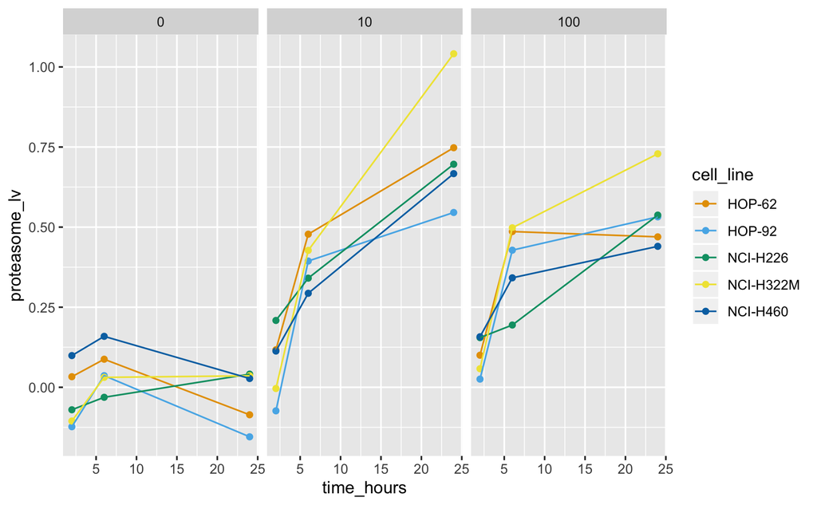

```r
# this is the main way we pass data to ggplot2 and tell it what values to
# plot on which axis, etc.
ggplot(lung_bortezomib_df,
       aes(x = time_hours,  # plot the time point on the x-axis
           y = proteasome_lv,  # plot the LV expression values on y-axis
           color = cell_line,  # color by individual cell line
           # we need to use group to make our line plot
           group = cell_line)) +  # the + operator allows us add layers
  geom_point() +  # we'll have points on our graph
  geom_line() +  # that are connected by a line
  facet_wrap(~ dose_nM) +  # use facets to separate dosages
  scale_color_OkabeIto()  # use this scale from colorblindr for accessibility
```

What do you think is happening in these samples?